# notebook

Ingeniería Financiera

Microestructura y Sistemas de Trading

I.F. Andrea Jiménez Orozco

Febrero 2021 | Repositorio: [Link](https://github.com/andreajimenezorozco/MyST_LAB1_AJI')

Laboratorio 1  
Inversión del Capital

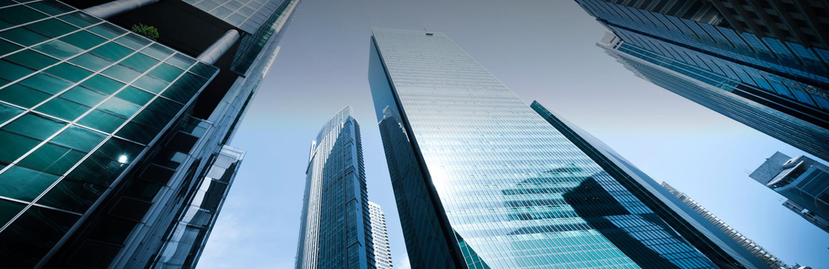

# Abstract

Este documento fue elaborado por **Andrea Jiménez Orozco**, como un trabajo parcial para la materia de **Microestructura y Sistemas de Trading**, la cual es parte del curriculum de la licenciatura en Ingeniería Financiera, ofertada por la universidad **ITESO**. En el presente trabajo se plantea la respuesta a la siguiente pregunta: *¿Qué estrategia de inversión propondrías si tu trabajo fuera administrar 1 Millón de pesos?*

# 0. Librerías y Dependencias

# 0.1 Librerías

Para correr este notebook es necesario tener instaladas y/o en el archivo *requirements.txt* las siguientes librerías :

- pandas>=1.1.1
- numpy>=1.19.1
- jupyter>=1.0.0
- yfinance>=0.1.54

# 0.2 Dependencias

Para correr este notebook es necesario contar con los siguientes archivos y dependencias externas:

- /files/NAFTRAC_holdings
- requirement.txt

# 1. Introducción

Algunas de las preguntas más frecuentes hacia cualquier financiero actualmente es **¿qué tipo de estrategia de inversión se debe ejecutar para administrar eficientemente un determinado capital?**

Desafortunadamente no existe una respuesta única, pues esta serie de pasos o criterios será diferente dependiendo de los resultados que se quieran alcanzar. Así como de factores más personales como el perfil del inversionista, sus conocimientos, herramientas, experiencia y demás.

Aquellos que conocen de mercados financieros entenderán muy bien que para lograr un resultado preciso se requiere de una minuciosa planeación y entendimiento de las múltiples - quizá hasta infinitas - variables que juegan un papel relevante para un determinado escenario.

Sin embargo como todo y partiendo de lo general, podemos encontrar algunos elementos abiertos al debate. Una serie de dilemas o mejor dicho decisiones, que se tienen que tomar para llegar al objetivo deseado. Que en dicho contexto se resume en cómo conseguir un rendimiento "bueno", "aceptable" o "competitivo" - adjetivos que varían según la naturaleza y el ambiente de la inversión.

Uno de estos elementos popularmente discutido y conocido trata sobre responder *¿qué es mejor, realizar una inversión activa del capital o tomar una postura pasiva?* Para entender más a fondo esta cuestión quizá tengamos que explicar brevemente a que se refiere cada una.

La **inversión pasiva** nace a raíz de analizar a los índices bursátiles, cuya función principal radica en servir de *benchmark* o referencia sobre el crecimiento y/o comportamiento de cierta industria. En el presente trabajo, utilizaremos de ejemplo como instrumento un **ETF** *(exchange-trade-fund)*, elaborados como vehículos de inversión para invertir de manera diversificada y a bajo costo.

Muchos de estos basan su elección y ponderación replicando a índices bursátiles, tal es el caso del **NAFTRAC**, creado en el año 2002 por *Nacional Financiera*, cuyo objetivo es posicionarlo como un referente del mercado mexicano a nivel global. Ya que las empresas listadas pertenecen al **S&P de la Bolsa Mexicana de Valores.**

Por lo tanto la estrategia de **inversión pasiva** no es más que querer alcanzar la misma rentabilidad que ofrece el mercado. Esto por supuesto implica ventajas como reducir el riesgo y los costes de administración, pero a su vez también un retorno mucho menor a corto y mediano plazo. Para conseguirlo se deben seleccionar inversiones, como ya se mencionó anteriormente, que copien otros índices, lo cual suele hacer al proceso mucho más sencillo, ya que requiere de poco esfuerzo y conocimientos generales que están al alcance de cualquier persona.

Por otro lado, siguiendo la misma lógica pero completamente opuesta. Una **inversión activa** es el proceso en el cual el inversor busca y escoge dichos activos basado en su propio criterio e investigación, con el fin de superar la rentabilidad ofrecida por el sector de referencia. No obstante para ello se requiere contar con un buen conocimiento y experiencia sobre el mercado, así como un perfil más abierto y resiliente al riesgo.

Entonces, **¿cuál de los dos modelos elegir?** Es la cuestión que se intentará responder al final del análisis.

[figure not shown]

# 2. Objetivos

La intención del presente trabajo es hacer una comparativa simple entre utilizar ambos tipos de inversión en el mismo periodo de tiempo. El cual comprende del **31 enero del 2018 al 31 de dicembre del 2020.**

Para crear una cartera de inversión pasiva, nos apoyaremos de un **ETF** *(exchange-trade-fund)* **NAFTRAC iShares de BlackRock** el cual réplica el índice mexicano **S&P - BMV**, cuya información disponible y archivos utilizados para el análsis se pueden encontrar en el siguiente [LINK](https://www.blackrock.com/mx/intermediarios/productos/251895/ishares-naftrac-fund).

De esta manera utilizando los mismos activos y un capital para ambas de $1,000,000 MXN, se consideraron los siguientes criterios:

**Inversión Pasiva**

- Compra de títulos utilizando el 100% del capital.
- Comision = $0.00125
- Solo se permiten posiciones en largo.
- Las operaciones se ejecutan al precio de cierre de mercado.
- Sin rebalanceos durante todo el periodo de análisis.
- El portafolio se forma a partir de las ponderaciones del primer mes.
- Por fines prácticas los activos **KOFL.MX, KOFUBL.MX, USD.MXN, BSMXB.MX, NMKA.MX**, se eliminaron de las posiciones históricas y se consideraron como **CASH**.

**Inversión Activa**

- Se considera la misma ponderación inicial y comisiones que la inversión pasiva.
- El activo con mayor ponderación utilizará solo el 50% de su capital destinado.
- El **CASH** disponible se compone de los mismos activos sin considerar de la inversión pasiva + el restante 50% del capital que no se utilizó para el activo con mayor ponderación. Resultando este en el **presupuesto de trading**.
- Para realizar el rebalanceo, se destinará el 10% del capital disponible en **CASH** para la adquisición de nuevos títulos en cada operación.
- Dicha adquisición de realizará solo para el activo con mayor ponderación y si este generó una señal bajista. Es decir, si al día anterior el precio de apertura fue mayor al precio de cierre con una variación de 1%.
- Tal señal deriva en una compra de títulos al precio de apertura del día siguiente inmediato hasta que se utilice el 100% del capital disponible.

  **Un vez establecidos los criterios de operación, las siguientes secciones de desarrollo tienen como objetivo describir de manera particular la metodología utilizada para llegar a los resultados finales.**

# 3. Datos

Dentro de la carpeta **/files** se encuentran todos los archivos en formato *.csv* con los activos utilizados mes con mes y sus respectivas ponderaciones durante el periodo de observación.

La información es importante para saber que peso darle a cada emisora a la hora de iniciar la inversión del capital. Por lo que se crearon diferentes funciones para leer de manera recursivas los datos, extraer fechas y englobar todo en un solo *DataFrame* que nos permitirá comenzar con el análisis.

La estructura de proyecto se basa en crear diferentes archivos de *python* los cuales mandamos llamar al inicio en una sola línea. Cada función tiene un objetivo distinto, consecutivo y complementario para la creación del análisis. Esto nos permite obtener como resultado una organización más limpia, funcional y eficiente, lo que se traduce en una mejor comprensión para el lector.

Los elementos son los siguientes:

- **main.py**

  ```
    Contiene el orden secuencial de las funciones principales para correr el análisis.
  ```

- **functions.py**

  ```
    Contiene todas las funciones referentes al cálculo de ambas estrategias.
  ```

- **data.py**

  ```
    Contiene todas las funciones referentes a la descarga y manejo de datos.
  ```

- **visualizations.py**

  ```
    Contiene todas las funciones correspondientes a la creación de gráficas y/o elementos visuales.
  ```

```python
# Importar liberías
import functions as fn
import data as dt
import visualizations as vz
import warnings
warnings.filterwarnings('ignore')
```

```python
# Extracción de fechas de los archivos
dates = fn.dates_for_files(path=r'files')

# Lectura recursiva
df = dt.multiple_csv(path=r'files')

# Limpieza de tickers utilizados como CASH y adición del componente ".MX" para la descarga de precios.
historical = fn.cleaning_data(df)
historical.head()
```

| Fecha | Ticker | Peso (%) |
| --- | --- | --- |
| 2018-01-31 | AMXL.MX | 0.1331 |
| 2018-01-31 | FEMSAUBD.MX | 0.1269 |
| 2018-01-31 | GFNORTEO.MX | 0.0951 |
| 2018-01-31 | WALMEX.MX | 0.0760 |
| 2018-01-31 | GMEXICOB.MX | 0.0754 |

Para poder observar la evolución del capital a lo largo del tiempo requeriemos descargar los precios históricos del periodo de observación para cada uno de los activos presentes en los archivos. Se utilizó la liberia de **yfinance** para obtener los precios de apertura y cierre diarios.

```python
# Lista de tickers únicos presentes en el histórico
tickers = fn.global_tickers(historical)

# Descarga de precios de apertura y cierre de las fechas de interés con frecuencia diaria.
open_ = dt.get_open(tickers, '2018-01-30', '2020-12-31', freq="d")
closes = dt.get_closes(tickers, '2018-01-30','2020-12-31', freq="d")
```

Finalmente, podemos englobar dichos precios, pesos, fechas y activos en una sola tabla para facilitar los próximos cálculos.

```python
global_df = dt.global_dataframe(historical, closes, open_, dates)
global_df.head()
```

|  | Ticker | Fecha | Peso (%) | Close | Open |
| --- | --- | --- | --- | --- | --- |
| 0 | AMXL.MX | 2018-01-31 | 0.1331 | 16.0147 | 17.43 |
| 1 | FEMSAUBD.MX | 2018-01-31 | 0.1269 | 170.509 | 181.2 |
| 2 | GFNORTEO.MX | 2018-01-31 | 0.0951 | 109.758 | 119.31 |
| 3 | WALMEX.MX | 2018-01-31 | 0.076 | 43.6713 | 45.3 |
| 4 | GMEXICOB.MX | 2018-01-31 | 0.0754 | 56.2879 | 65.51 |

# 4. Procesos

## 4.1 Inversión Pasiva

## 4.1.2 Inicialización

La incialización de la **inversión pasiva** consta de obtener las ponderaciónes iniciales a la fecha de inicio, calculo de títulos correspondientes, comisiones y **CASH** disponible.

Como se puede observar en la siguiente tabla, la función *passive_weights()* filtra y calcula los elementos necesarios para incializar la posición. La cual requiere de los siguientes argumentos:

- DataFrame histórico que debe contener activos, fechas, peso y precios.
- Fechas extraidas de los archivos en los cuales se hará corte de la posción mes con mes.
- Capital
- Comision

**La salida corresponde a las 32 emisoras presentes al 31 de enero del 2018 - Sin considerar aquellas que se mandaron para CASH.**

```python
passive_weights = fn.passive_weights(global_df, dates, 1000000, 0.00125)
passive_weights.head()
```

|  | Ticker | Titulos | Peso (%) fijo | Capital | Close | Comision |
| --- | --- | --- | --- | --- | --- | --- |
| 0 | AMXL.MX | 8311 | 0.1331 | 133100.0 | 16.0147 | 166.373 |
| 1 | FEMSAUBD.MX | 744 | 0.1269 | 126900.0 | 170.509 | 158.574 |
| 2 | GFNORTEO.MX | 866 | 0.0951 | 95100.0 | 109.758 | 118.813 |
| 3 | WALMEX.MX | 1740 | 0.0760 | 76000.0 | 43.6713 | 94.9852 |
| 4 | GMEXICOB.MX | 1339 | 0.0754 | 75400.0 | 56.2879 | 94.2118 |

## 4.1.3 Evolución del capital

Para la evolución del capital a lo largo del tiempo, es necesario multiplicar los títulos iniciales - sin cambios a lo largo del periodo - por el precio diario. Recordemos que en este tipo de inversión las comisiones se extrajeron una sola vez al comienzo y el **CASH** se mantuvo sin cambios.

*El calculo del capital corresponde a la siguiente formula:*

**CAPITAL = POSTURA (1) + CASH (2) - COMISIONES (3)**

```
(1) Títulos *n-Activo* x *n-día Precio* de todos los activos iniciales
(2) 100% - Pesos (%).sum() = [ Cash (%) * Capital ]
(3) Comision.sum() = Títulos *n-Activo* x *n-Precio* x $0.00125
```

Finalmente agrupamos por las fechas fijas provenientes de los archivos y calculamos el rendimiento mensual Vs. Capital ($1,000,000 MXN) y rendimiento acumulado.

- Nota: La función *passive_investment()* contenida en main.py recibe los mismos argumentos que la función de *passive_weights()*, esta ultima se manda llamar dentro para realizar los calculos restantes y previamente descritos en esta sección.

```python
passive = fn.passive_investment(global_df,dates,1000000,0.00125)
passive.head()
```

|  | Capital | Rend. (%) | Rend. Acum (%) |
| --- | --- | --- | --- |
| 2018-01-30 | 1000000.00 | 0.000000 | 0.0000 |
| 2018-01-31 | 998065.87 | -0.001934 | -0.0019 |
| 2018-02-28 | 944246.94 | -0.055753 | -0.0577 |
| 2018-03-28 | 919759.29 | -0.080241 | -0.1379 |
| 2018-04-30 | 965480.66 | -0.034519 | -0.1724 |

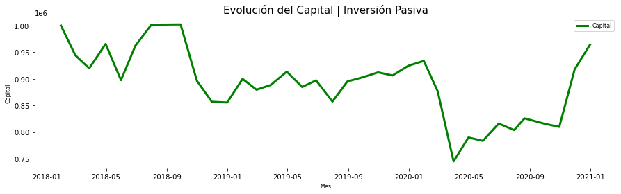

```python
vz.basic_plot(passive,"Evolución del Capital | Inversión Pasiva", "Capital","Mes","Capital")
```

## 4.2 Inversión Activa

#### 4.2.1 Inicialización

La incialización de la **inversión activa** consta de la misma lógica que la **inversión pasiva** salvo que en esta ocación el activo con mayor peso utilizará el 50% de su ponderación o capital asignado en un principio. Siendo el resto **CASH** disponible como parte del *presupuesto de trading*.

Como se puede observar en la siguiente tabla, la función *active_weights()* filtra y calcula los elementos necesarios para incializar la posición. La cual requiere de los siguientes argumentos:

- *DataFrame* histórico que debe contener activos, fechas, pesos y precios.
- Fechas extraidas de los archivos en los cuales se hará corte de la posción mes con mes.
- Capital
- Comision

A diferencia de la función de pesos para la inversión pasiva, *active_weights()* regresa dos elementos. El primero un *DataFrame* con los activos, títulos, comisiones y precios. Y el segundo el **CASH** disponible como *presupuesto de trading* que utilizaremos más adelante.

**La salida corresponde a las 32 emisoras presentes al 31 de enero del 2018 - Sin considerar aquellas que se mandaron para CASH.**

```python
active_weights = fn.active_weights(global_df,dates,1000000,0.00125)[0]
active_weights.head()
```

|  | Ticker | Titulos | Peso (%) | Close | Comision |
| --- | --- | --- | --- | --- | --- |
| 0 | AMXL.MX | 4155.0 | 0.06655 | 16.0147 | 83.1766 |
| 1 | FEMSAUBD.MX | 744.0 | 0.12690 | 170.509 | 158.574 |
| 2 | GFNORTEO.MX | 866.0 | 0.09510 | 109.758 | 118.813 |
| 3 | WALMEX.MX | 1740.0 | 0.07600 | 43.6713 | 94.9852 |
| 4 | GMEXICOB.MX | 1339.0 | 0.07540 | 56.2879 | 94.2118 |

```python
cash = fn.active_weights(global_df,dates,1000000,0.00125)[1]
cash
```

```
112129.57941259025
```

#### 4.2.2 Rebalanceo

La particularidad de la **inversión activa** es la personalización de los criterios para rebalancear o invertir el capital. En este caso, el criterio central fue empezar con una posición netural en el activo con mayor peso, el cual fue **Ámerica Móvil (AMXL.MX)**.

Lo cual hace bastante sentido, pues es una de las empresas mexicanas más grandes, exitosas y estables del país. Y por ende ocupa un puesto importante en el índice **S&P** mexicano. La intención es ver la la evolución del capital conforme se va aumentando la exposición en el activo cada vez que este se puede comprar a un precio menor.

Por lo que nuevamente recordando, cada vez que se genere una **señal bajista**, es decir el precio de apertura fue mayor que el precio de cierre. Se mandará la orden de comprar nuevos títulos al día inmediato siguiente.

Cada operación cuenta con un 10% del *presupuesto de trading* el cual irá disminuyendo hasta que se haya utilizado en su totalidad. Es de vital importancia agregar estos nuevos títulos al mes correspondiente así como las comisiones generadas por dichas operaciones para calcular la evolución del capital.

La función *new_titles()* nos regresa un histórico de operaciones de los días en donde se ejecutó una compra dado una señal bajista al día inmediato anterior.

Para ello fue necesario filtar los precios de apertura y cierre solo del activo en cuestión y calcular la variación. Esta última se establece como parámetro dado que se abre la posibilidad de generar diferentes escenarios que no necesariamente correspondan al 1%.

Una vez generado este *DataFrame* con solo las operaciones de compra, se realizó una iteración para calcular el monto destinado a la operación, títulos, comisiones y el nuevo **CASH** disponible para la siguiente señal. Esto hasta que ya no se pudieron comprar más títulos.

Como se puede observar en la siguiente tabla, la función *new_titles()* filtra y calcula los elementos necesarios para la compra de nuevos títulos. La cual requiere de los siguientes argumentos:

- *DataFrame* histórico que debe contener activos, fechas, peso y precios.
- Fechas extraidas de los archivos en los cuales se hará corte de la posción mes con mes.
- Capital
- Comision
- Precios de apertura
- Precios de cierre
- Variación a la cual se estará mandando la señal de compra

**La salida corresponde a las fechas en las que solamente se generó la señal de compra un dia inmediato anterior.**

```python
historicos_op = fn.new_titles(global_df, dates, 1000000, 0.00125, open_, closes, 0.01)
historicos_op.head()
```

| Fecha | Ticker | Open | Cash | Presupuesto | Comision | Comision acum. | Titulos totales | Titulos comprados |
| --- | --- | --- | --- | --- | --- | --- | --- | --- |
| 2018-01-31 | AMXL.MX | 17.25 | 112129.58 | 0.00 | 0.00 | 0.00 | 4155.0 | 0.0 |
| 2018-02-01 | AMXL.MX | 17.33 | 100902.61 | 11212.96 | 14.02 | 14.02 | 4802.0 | 647.0 |
| 2018-02-02 | AMXL.MX | 17.41 | 90799.74 | 10090.26 | 12.60 | 26.62 | 5381.0 | 579.0 |
| 2018-02-06 | AMXL.MX | 16.61 | 81708.43 | 9079.97 | 11.34 | 37.96 | 5927.0 | 546.0 |
| 2018-02-07 | AMXL.MX | 17.05 | 73527.38 | 8170.84 | 10.21 | 48.17 | 6406.0 | 479.0 |